# Comparative Genomics Tutorial

# Tutorial Outline

1. Introduction
2. Human - Mouse synteny
   1. Detect syntenic relationships
   2. Generate syntenic dot plot - whole genome
   3. Generate dual synteny plot
3. Whole genome duplication
   1. Detect_syntenic_tandem_arrays
   2. Dissect_multiple_alignment
   3. Generate syntenic dot plot
   4. Generate dual synteny plot
   5. Generate circular synteny plot
4. Raspberry (Rubus) - Strawberry (Fragaria) genome comparison
   1. Generate syntenic dot plot

# 1. Introduction

Genomes of living organisms consist of genes and noncoding DNA arranged in particular orders on one or more chromosomes. Eukaryotes usually have several pairs of linear chromosomes (humans have 23 pairs in each somatic cell), but prokaryotes typically have only one or a few circular (sometimes linear) chromosomes. The order of genes (or sets of genes) along a particular chromosome of a particular species is ordinarily conserved, and the list of genes or physical markers along a genome, together with the distances between these genes or markers, is called either a genetic or physical map, depending upon the units in which distances are measured. For each species, there is a particular genetic map that distinguishes it from other species. These genetic maps and genome sequences of contemporary organisms contain a record of changes that have occurred over time. The types of changes that may have occurred include:

> **Deletion:** Removal of one or more contiguous bases.  
> **Insertion:** Insertion of one or more contiguous bases between adjacent nucleotides in a DNA sequence. This is often associated with insertion of transposable elements.  
> **Segmental duplication:** Appearance of two or more copies of the same extended portion of the genome in different locations in the DNA sequence.  
> **Inversion:** Reversal of the order of genes or other DNA markers in a subsequence relative to flanking markers in a longer sequence. Within a longer sequence, inversion replaces one strand of the subsequence with its complement, maintaining 5′ to 3′ polarity.  
> **Translocation:** Placement of a chromosomal segment into a new se- quence context elsewhere in the genome.  
> **Recombination:** In vivo joining of one DNA sequence to another. When similar sequences are involved, this is called homologous recombination. Point mutation: Substitution of the base usually found at a position in the DNA by another as a result of an error in base insertion by DNA polymerase or misrepair after chemical modification of a base.

For example, even though the mouse (*Mus musculus*) contains most of the same types of genes found in humans, the genetic map of the mouse differs from that of humans. This is illustrated in Fig. 1 for human (*Homo sapiens*) chromosome Hsa6, which contains blocks of DNA sequences corresponding to portions of six different mouse chromosomes.

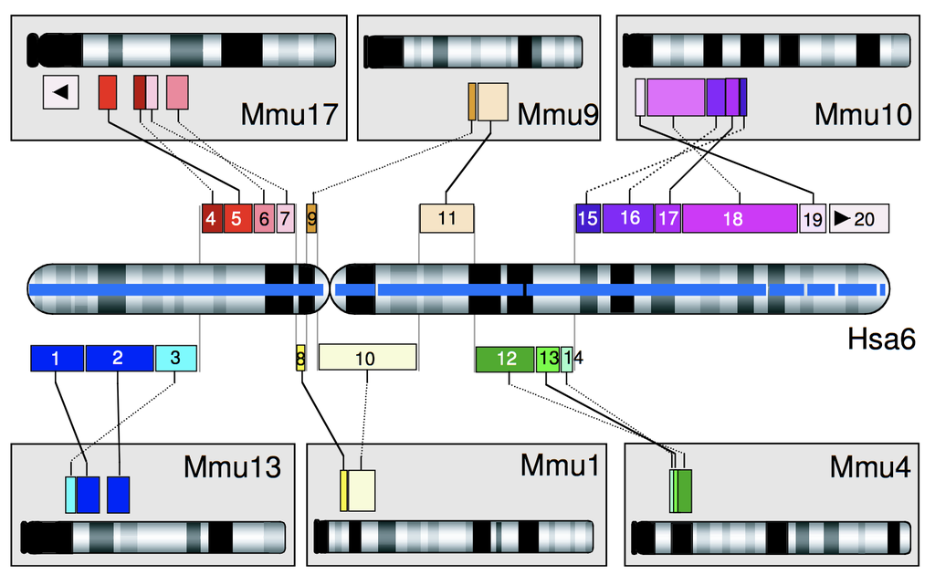

> **Figure 1:** Syntenic blocks conserved between human chromosome Hsa6 and mouse chromosomes. Broken lines indicate regions that appear in inverted orders in the two organisms. Reprinted from Gregory SG et al. (2002) Nature 418:743–750.

Clearly, segments of DNA in the two species were rearranged with respect to each other during their independent descent from a common ancestor. If blocks of sequences are excised from one location and inserted into another, those sequences are said to have been translocated. On the other hand, it is possible that the chunks of sequence in a syntenic block remain together but are permuted in one organism relative to the other. An example of permutation is blocks 1-2-3 of Hsa6 in Fig. 1, which appear in the order 3-1-2 in the mouse chromosome Mmu13. Sometimes sequences in the genome of an organism are duplicated elsewhere in the same genome (either on the same or on a different chromosome). For example, it is estimated that around 5% of the human genome (exclusive of transposable elements) consists of duplicated sequences (Bailey et al., 2002).

When comparing genomes of two organisms such as mice and humans, we sometimes observe local similarities in the gene content and gene order. If two or more genes that occur together on a single chromosome in organism B also occur together on a particular chromosome in organism C, this occurrence is an example of **conserved synteny**. As shown in Fig. 1, the gene orders may or may not be conserved within syntenic blocks that are distributed among different chromosomes in a related organism.

# 2. Human - Mouse synteny

In this example, we will be generating the syntenic relationships between human and mouse genomes in a way that is similar to Fig. 1. To do this, we need to get the reference genome information for each species and in particular, we would need to download the protein fasta and gff files. These files are located in the following locations on *bioinformatics*:

Human: Release 30 (GRCh38.p12) - https://www.gencodegenes.org/human/

> /home/WWU/BIOL497R/data/CompGen/gencode.v30.pc_primary.fa  
> /home/WWU/BIOL497R/data/CompGen/gencode.v30.gene_only.gff3

Mouse: Release M21 (GRCm38.p6) - https://www.gencodegenes.org/mouse/

> /home/WWU/BIOL497R/data/CompGen/gencode.vM21.pc_primary.fa  
> /home/WWU/BIOL497R/data/CompGen/gencode.vM21.gene_only.gff3

The analysis of syntenic regions between or within species genomes requires the user to generate a large blast database that compares all protein sequences and identifies sequences that are similar based on user defined thresholds.

For this analysis to generate more reasonable synteny results, the number of BLASTP hits for a gene should be restricted to around top 5 (`-b 5 -v 5`). In addition, we want to identify sequences that have a high degree of similarity and to do this we specify an e-value threshold (`-e 1e-10`). More infomation on e-values can be found [here](http://www.metagenomics.wiki/tools/blast/evalue).  
Example bash code:

```
DATA=/home/WWU/BIOL497R/data/CompGen

#first genenerate a blast database
makeblastdb -in $DATA/gencode.v30.pc_primary.fa -dbtype prot

#second blast Mouse (query) versus Human (ref)
blastall -a 40 -i $DATA/gencode.vM21.pc_primary.fa  \
    -d $DATA/gencode.v30.pc_primary.fa -p blastp  \
    -e 1e-10 -b 5 -v 5 -m 8 -o human/human_mouse.blast
```

These results can be found at:

```
~/BIOL497R/notebooks/Ex6_ComparativeGenomics/human/human_mouse.blast
```

## A. Detect syntenic relationships

Next we need to run the program `MCScanX`, which parses the blastp results to detect syntenic blocks and progressively aligns multiple syntenic blocks against reference genomes. To do this, MCscanX reads in two data files.

The `human_mouse.blast` file is simply the direct BLASTP output of m8 format as following:

```
ENSMUSG00000000001.4    ENSG00000065135.11      98.31   354     6       0       1       354     1       354     0.0      688
ENSMUSG00000000001.4    ENSG00000127955.17      93.79   354     22      0       1       354     1       354     0.0      664
ENSMUSG00000000001.4    ENSG00000114353.17      84.62   312     47      1       44      354     28      339     0.0      566
```

The `human_mouse.gff` file was generated by concatinating the two gff3 and reformated to the following tab-delimited format:

```
Hsa1    ENSG00000186092.6       65419   71585
Hsa1    ENSG00000284733.1       450703  451697
Hsa1    ENSG00000284662.1       685679  686673
.
.
.
MmuM    ENSMUSG00000064367.1    11742   13565
MmuM    ENSMUSG00000064368.1    13552   14070
MmuM    ENSMUSG00000064370.1    14145   15288
```

```python
%%bash

MCScanX  human/human_mouse
```

The execution of MCScanX outputs one text file `human_mouse.collinearity`, containing pairwise syteny blocks as follows:

```
## Alignment 0: score=1294.0 e_value=7.6e-82 N=26 Hsa1&Mmu1 plus
  0-  0:        ENSG00000155816.20      ENSMUSG00000028354.13     3e-88
  0-  1:        ENSG00000180875.5       ENSMUSG00000050069.3     3e-108
  0-  2:        ENSG00000182901.16      ENSMUSG00000026527.13         0
  .
  .
  .
## Alignment 1: score=306.0 e_value=1.1e-11 N=7 Hsa1&Mmu1 plus
  1-  0:        ENSG00000143297.19      ENSMUSG00000070504.9      9e-20
  1-  1:        ENSG00000180708.5       ENSMUSG00000037924.6      6e-99
  1-  2:        ENSG00000173285.4       ENSMUSG00000062527.6     6e-100
```

## B. Generate syntenic dot plot - whole genome

This java script generates a dot plot for all the syntenic blocks on two sets of chromosomes given by the user.

Usage:

```
java dot_plotter -g gff_file -s synteny_file -c control_file -o output_PNG_file
```

The input files include a gff file containing all gene positions, a synteny/collinearity file generated by MCScanX, and a control file (.ctl) containing plot size and chromosome IDs. The control file can be easily made by modifying the `hm_dot.ctl` file:

```
1800    //dimension (in pixels) of x axis
1800    //dimension (in pixels) of y axis
Hsa1,Hsa2,Hsa3,Hsa4,Hsa5,Hsa6,Hsa7,Hsa8,Hsa9,Hsa10,Hsa11,Hsa12,Hsa13,Hsa14,Hsa15,Hsa16,Hsa17,Hsa18,Hsa19,Hsa20,Hsa21,Hsa22,HsaM,HsaX,HsaY,   //chromosomes in x axis
Mmu1,Mmu2,Mmu3,Mmu4,Mmu5,Mmu6,Mmu7,Mmu8,Mmu9,Mmu10,Mmu11,Mmu12,Mmu13,Mmu14,Mmu15,Mmu16,Mmu17,Mmu18,Mmu19,MmuM,MmuX,MmuY,   //chromosomes in y axis
```

Note that no space is allowed between adjacent chromosome IDs.

**Output:**

Output is an image file (PNG format) which can be viewed with an image viewer. Each dot is a sytenic gene pair between the two sets of chromosomes. Different colors of dots, generated randomly, represent different syntenic blocks.

```python
%%bash

cd downstream_analyses/

java dot_plotter -g ../human/human_mouse.gff -s ../human/human_mouse.collinearity -c hm_dot.ctl -o ../human/human_mouse_dot.png
```

## C. Generate dual synteny plot

Usage:

```
java dual_synteny_plotter -g gff_file -s synteny_file -c control_file -o output_PNG_file
```

The input files include a gff file containing all gene positions, a synteny/collinearity file generated by MCScanX, and a control file (.ctl) containing plot size and chromosome IDs. The control file can be easily made by modifying the `column.ctl` file:

```
600     //plot width (in pixels)
1800     //plot height (in pixels)
Hsa1 //chromosomes in the left column
Mmu1,Mmu3,Mmu4,Mmu8,Mmu10,Mmu11,Mmu13     //chromosomes in the right column
```

Note that no space is allowed between adjacent chromosome IDs.

**Output:**

Output is an image file (PNG format) which can be viewed with an image viewer. Each line links a pair of syntenic genes between the two sets of chromosomes. Different colors of lines, generated randomly, represent different syntenic blocks.

```python
%%bash

cd downstream_analyses/

java dual_synteny_plotter -g ../human/human_mouse.gff -s ../human/human_mouse.collinearity -c hm_column.ctl -o ../human/human_mouse_dual_syn.png
```

# 3. Whole genome duplication

In the example, we are going to generate a list of syntenic genes within the *Populus* genome (version 210). *Populus* and all Salicaceae under went a recent whole genome duplication about 60 mya (Tuskan et al., 2006) and this resulted in many of the genes in the genome having a shared ancentral history and these duplicated genes are commonly refered to as paralogs.

First, we would need to generate the blast comparison between all pairwise combinations of protein sequences in *Populus* and this step takes a long time (60-80 min). Here is a typical parameter setting for generating the `pt210.blast` file.

Example bash code:

```
DATA=/home/WWU/BIOL497R/data/CompGen

#first genenerate a blast database
makeblastdb -in $DATA/Ptrichocarpa_210_v3.0.protein_primaryTranscriptOnly.fa -dbtype prot

#second blast Populus versus Populus
blastall -a 4 -i $DATA/Ptrichocarpa_210_v3.0.protein_primaryTranscriptOnly.fa  \
    -d $DATA/Ptrichocarpa_210_v3.0.protein_primaryTranscriptOnly.fa -p blastp  \
    -e 1e-10 -b 5 -v 5 -m 8 -o populus/pt210.blast
```

These results have already been genearted and can be found at:

```
~/BIOL497R/notebooks/Ex6_ComparativeGenomics/populus/pt210.blast
```

Next, we need to run the program `MCScanX`, which parses the blastp results to detect syntenic blocks and progressively aligns multiple syntenic blocks against reference genomes. To do this, MCscan2 reads in two data files.

The `pt210.blast` file is simply the direct BLASTP output of m8 format as following:

```
Potri.T155100   Potri.T155100   100.00  103 0   0   1   103 1   103 3e-71    207
Potri.T155100   Potri.002G022700    83.50   103 15  2   1   103 1   101 5e-47    145
```

The `pt210.gff` file holds gene positions, following a tab-delimited format:

```
pt1 Potri.001G000100    1659    2502
pt1 Potri.001G000200    2905    6646
pt1 Potri.001G000300    8390    8860
```

```python
%%bash

MCScanX  populus/pt210
```

The execution of MCScanX outputs one text file `pt210.collinearity`, containing pairwise syteny blocks as follows:

```
## Alignment 0: score=286.0 e_value=2.8e-10 N=6 pt1&pt1 plus
  0-  0:        Potri.001G443400        Potri.001G445000              0
  0-  1:        Potri.001G443500        Potri.001G445100          5e-90
  0-  2:        Potri.001G443900        Potri.001G445600              0
  0-  3:        Potri.001G444200        Potri.001G445800          1e-97
  0-  4:        Potri.001G444800        Potri.001G446500          6e-33
  0-  5:        Potri.001G444900        Potri.001G446800          1e-34
## Alignment 1: score=252.0 e_value=3.6e-08 N=6 pt1&pt1 plus
  1-  0:        Potri.001G422900        Potri.001G432500          5e-63
  1-  1:        Potri.001G425400        Potri.001G433300         2e-174
  1-  2:        Potri.001G425800        Potri.001G433800         1e-100
```

## A. Detect_syntenic_tandem_arrays

Tandem duplications often complicate synteny detection. To enhance the power of synteny detection, MCScan algorithms use the gene with best BLASTP hit to represent a tandem array. This program transforms match genes in syntenic blocks into tandem arrays if tandem duplications exist there.

Usage:

```
./detect_syntenic_tandem_arrays -g gff_file -b blast_file -s synteny_file -o output_file
```

**Output:**

The path of output_file should be specified by the user. If any gene of a syntenic pair is located in a tandem array, the syntenic pair will be written into the output_file.

```python
# this program does not like running with %%bash
# running the !bash_command

!detect_syntenic_tandem_arrays -g populus/pt210.gff -b populus/pt210.blast -s populus/pt210.collinearity -o populus/pt210.tandem_arrays
```

## B. Dissect_multiple_alignment

This program dissects the number of syntenic blocks at each gene locus of the reference genome(s) into the number of intra-species syntenic blocks and the number of inter-species syntenic blocks.

Usage:

```
./dissect_multiple_alignment -g gff_file -c collinearity_file -o output_file
```

**Output:**

```python
!dissect_multiple_alignment -g populus/pt210.gff -c populus/pt210.collinearity -o populus/pt210_multiple_alignment
```

## C. Generate syntenic dot plot

This java script generates a dot plot for all the syntenic blocks on two sets of chromosomes given by the user.

Usage:

```
java dot_plotter -g gff_file -s synteny_file -c control_file -o output_PNG_file
```

The input files include a gff file containing all gene positions, a synteny/collinearity file generated by MCScanX, and a control file (.ctl) containing plot size and chromosome IDs. The control file can be easily made by modifying the `dot.ctl` file:

```
1800    //dimension (in pixels) of x axis
1800    //dimension (in pixels) of y axis
pt1,pt2,pt3,pt4,pt5,pt6,pt7,pt8,pt9,pt10,pt11,pt12,pt13,pt14,pt15,pt16,pt17,pt18,pt19   //chromosomes in x axis
pt1,pt2,pt3,pt4,pt5,pt6,pt7,pt8,pt9,pt10,pt11,pt12,pt13,pt14,pt15,pt16,pt17,pt18,pt19   //chromosomes in y axis
```

Note that no space is allowed between adjacent chromosome IDs.

**Output:**

Output is an image file (PNG format) which can be viewed with an image viewer. Each dot is a sytenic gene pair between the two sets of chromosomes. Different colors of dots, generated randomly, represent different syntenic blocks.

```python
%%bash

cd downstream_analyses/

java dot_plotter -g ../populus/pt210.gff -s ../populus/pt210.collinearity -c dot.ctl -o ../populus/pt210_dot.png
```

## D. Generate dual synteny plot

This java script generates a dual synteny plot which links all the synteny blocks between two sets of chromosomes using straight lines.

Usage:

```
java dual_synteny_plotter -g gff_file -s synteny_file -c control_file -o output_PNG_file
```

The input files include a gff file containing all gene positions, a synteny/collinearity file generated by MCScanX, and a control file (.ctl) containing plot size and chromosome IDs. The control file can be easily made by modifying the `column.ctl` file:

```
600     //plot width (in pixels)
1800     //plot height (in pixels)
pt1 //chromosomes in the left column
pt3,pt,pt9,pt11,pt17     //chromosomes in the right column
```

Note that no space is allowed between adjacent chromosome IDs.

**Output:**

Output is an image file (PNG format) which can be viewed with an image viewer. Each line links a pair of syntenic genes between the two sets of chromosomes. Different colors of lines, generated randomly, represent different syntenic blocks.

```python
%%bash

cd downstream_analyses/

java dual_synteny_plotter -g ../populus/pt210.gff -s ../populus/pt210.collinearity -c column.ctl -o ../populus/pt210_dual_syn.png
```

## E. Generate circular synteny plot

This Java scripts generates a circular plot which links all the syntenic blocks with curved lines between and within the chromosome set given by users.

Usage:

```
java circle_plotter -g gff_file -s synteny_file -c control_file -o output_PNG_file
```

The input files include a gff file containing all gene positions, a synteny/collinearity file generated by MCScanX, and a control file (.ctl) containing plot size and chromosome IDs. The control file can be easily made by modifying the circle.ctl file:

```
1800     //plot width and height (in pixels)
pt1,pt2,pt3,pt4,pt5,pt6,pt7,pt8,pt9,pt10,pt11,pt12,pt13,pt14,pt15,pt16,pt17,pt18,pt19    //chromosomes in the circle
```

Note that no space is allowed between adjacent chromosome IDs.

**Output:**

Output is an image file (PNG format) which can be viewed with an image viewer. Each curved line links a pair of syntenic genes between or within the given set of chromosomes. Different colors of lines, generated randomly, represent different syntenic blocks.

```python
%%bash

cd downstream_analyses/

java circle_plotter -g ../populus/pt210.gff -s ../populus/pt210.collinearity -c circle.ctl -o ../populus/pt210_circle.png
```

# 4. Raspberry (Rubus) - Strawberry (Fragaria) genome comparison

In this part of the exercise, we are going to generate a syntenic dot plot between the *Rubus occidentalis* v1 genome and *Fragaria vesca* v4.0 genome. This should be similar to the results that we discussed in our Friday discussion of the VanBuren paper but the Rubus v1 genome was more fragmented and contained numerious mis-assemblies.

Generating the blast results for all proteins in a genome takes a long time (~2 hours). Here is a typical parameter setting for generating the `Rocc_Fvesca.blast` file.

Example bash code:

```
DATA=/home/WWU/BIOL497R/data/CompGen

#first genenerate a blast database
makeblastdb -in $DATA/makeblastdb -in Rubus_occidentalis_v1.0.a1.proteins.fasta -dbtype prot

#second blast Populus versus Populus
blastall -a 4 -i $DATA/Fragaria_vesca_v4.0.a1_makerStandard_proteins.fasta  \
    -d $DATA/Rubus_occidentalis_v1.0.a1.proteins.fasta -p blastp  \
    -e 1e-10 -b 5 -v 5 -m 8 -o Rubus_Fragaria/Rocc_Fvesca.blast
```

These results have already been genearted and can be found at:

```
~/BIOL497R/notebooks/Ex6_ComparativeGenomics/Rubus_Fragaria/Rocc_Fvesca.blast
```

Next we need to run the program `MCScanX`, which parses the blastp results to detect syntenic blocks and progressively aligns multiple syntenic blocks against reference genomes. To do this, MCscan2 reads in two data files.

The `Rocc_Fvesca.gff` file holds gene positions, following a tab-delimited format and was generated by concatinating the individual gff files togeher with `cat`:

```
fv1 FvH4_c1g00020   2432    2674
fv1 FvH4_c1g00310   61177   63300
fv1 FvH4_c1g00060   11835   12041
.
.
.
ro1 Bras_G00001 1023    9108
ro1 Bras_G00002 10022   10333
ro1 Bras_G00003 11180   13350
```

Now we are ready to run MCScanX on the results of the Strawberry and Raspberry protein sequences

```python
%%bash

MCScanX  Rubus_Fragaria/Rocc_Fvesca
```

The execution of MCScanX outputs one text file `Rocc_Fvesca.collinearity`, containing pairwise syteny blocks as follows:

```
## Alignment 2: score=327.0 e_value=1.1e-10 N=7 Fvb1&ro132 plus
  2-  0:        FvH4_1g19770    Bras_G14132       1e-40
  2-  1:        FvH4_1g19780    Bras_G14134       7e-39
  2-  2:        FvH4_1g19830    Bras_G14139      3e-169
  2-  3:        FvH4_1g19840    Bras_G14148      1e-154
  2-  4:        FvH4_1g19880    Bras_G14152           0
  2-  5:        FvH4_1g19920    Bras_G14156      2e-155
  2-  6:        FvH4_1g19970    Bras_G14159       3e-75
## Alignment 3: score=270.0 e_value=1.8e-13 N=6 Fvb1&ro14 minus
  3-  0:        FvH4_1g30070    Bras_G04110           0
  3-  1:        FvH4_1g30090    Bras_G04109       9e-86
  3-  2:        FvH4_1g30100    Bras_G04108       2e-96
  3-  3:        FvH4_1g30150    Bras_G04104           0
```

## A. Generate syntenic dot plot

This java script generates a dot plot for all the syntenic blocks on two sets of chromosomes given by the user.

Usage:

```
java dot_plotter -g gff_file -s synteny_file -c control_file -o output_PNG_file
```

The input files include a gff file containing all gene positions, a synteny/collinearity file generated by MCScanX, and a control file (.ctl) containing plot size and chromosome IDs. The control file can be easily made by modifying the `Species_dot.ctl` file:

```
1800    //dimension (in pixels) of x axis
1800    //dimension (in pixels) of y axis
ro1,ro2,ro3,ro4,ro5,ro6,ro7 ... ro50   //chromosomes in x axis
Fvb1,Fvb2,Fvb3,Fvb4,Fvb5,Fvb6,Fvb7   //chromosomes in y axis
```

Note that no space is allowed between adjacent chromosome IDs.

**Output:**

Output is an image file (PNG format) which can be viewed with an image viewer. Each dot is a sytenic gene pair between the two sets of chromosomes. Different colors of dots, generated randomly, represent different syntenic blocks.

```python
%%bash

cd downstream_analyses/

java dot_plotter -g ../Rubus_Fragaria/Rocc_Fvesca.gff -s ../Rubus_Fragaria/Rocc_Fvesca.collinearity -c Species_dot.ctl -o ../Rubus_Fragaria/Rocc_Fvesca_dot.png
```